# Issue #76: ITTの問題を克服するために、PSM-DIDのストラテジーを利用した推定

## 雇用形態を操作変数としてIV推定（First-stage Result）

以下の就業形態に関する変数を用いる

- `p_aa005`：雇用形態（1=常用職2=臨時職日雇い3=自営業4=無給家族従事者）
- `paa008`：産業
  - 農業
  - 林業や漁業
  - 鉱業
  - 製造業
  - 電気、ガスおよび水道事業
  - 下水∙、廃棄物処理、原料再生および環境ボクウォンオプ
  - 建設業
  - 卸売や小売業
  - 運輸業
  - 宿泊と飲食店業
  - 出版、映像、放送通信や情報サービス業
  - 金融および保険業
  - 不動産業及び賃貸業
  - 専門科学および技術サービス業
  - 事業施設管理および事業支援サービス業
  - 公共行政、国防や、社会保障、行政
  - 教育サービス業
  - 保険業や社会福祉サービス業
  - 芸術、スポーツや余暇関連サービス業
  - 協会や団体、修理および個人サービス業
  - 世帯内雇用活動と違って分類されていない者が消費、生産活動
  - 国際および外国機関

`p_aa005`で常用職かどうかのダミー変数を作成する。`paa008`は共変量としてコントロールする

employeeかどうかで控除申請に差があるかどうかを記述統計で確認する

この図のメッセージ：self-employedと比較して、employeeの方が申請している

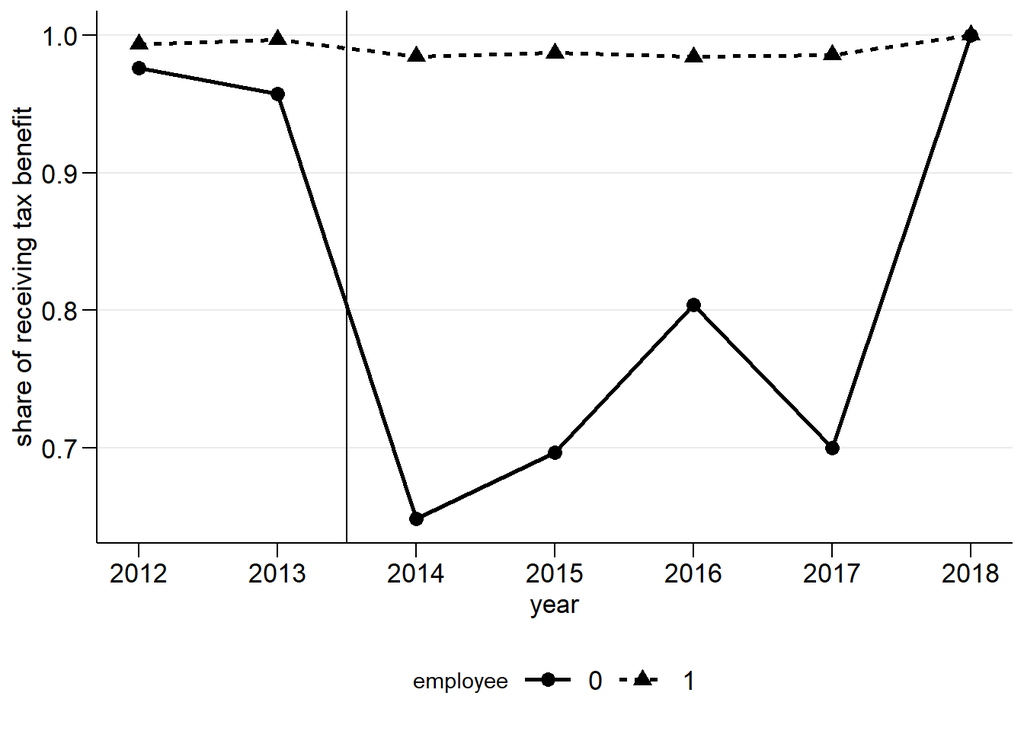

```r
df %>%
  dplyr::filter(!is.na(employee)) %>%
  group_by(year, employee) %>%
  summarize_at(vars(ext_benefit), list(~ mean(., na.rm = TRUE))) %>%
  mutate(employee = factor(employee)) %>%
  ggplot(aes(x = year, y = ext_benefit, group = employee)) +
  geom_point(aes(shape = employee), color = "black", size = 3) +
  geom_line(aes(linetype = employee), size = 1) +
  geom_vline(aes(xintercept = 2013.5)) +
  scale_x_continuous(breaks = seq(2012, 2018, 1)) +
  labs(y = "share of receiving tax benefit") +
  ggtemp()
```

推定モデルは

$$D_{it} \ln p_{it}
= \alpha_i + \gamma_1 \text{Employee}_{it} +
X_{it} \gamma_2 + \lambda_t + \epsilon_{it}$$

where $D_{it}$ is a dummy of tax report.

```r
xlist <- list(
  ~ employee,
  ~ employee + log_pinc_all + age + sqage +
    factor(year):factor(educ) + factor(year):factor(gender),
  ~ employee + log_pinc_all + age + sqage +
    factor(year):factor(educ) + factor(year):factor(gender) +
    factor(year):factor(indust)
)

xlist_tab <- tribble(
  ~vars, ~stat, ~reg1, ~reg2, ~reg3,
  "Time FE", "vars", "Y", "Y", "Y",
  "log(income)", "vars", "N", "Y", "Y",
  "Age", "vars", "N", "Y", "Y",
  "Year x Education", "vars", "N", "Y", "Y",
  "Year x Gender", "vars", "N", "Y", "Y",
  "Year x Resident Area", "vars", "N", "Y", "Y",
  "Dummy of industry", "vars", "N", "N", "Y"
)

est_benefit1 <- xlist %>%
  purrr::map(~ est_felm(
    y = int_price_benefit ~ ., x = .,
    fixef = ~ year, cluster = ~ pid,
    data = subset(df, 2014 <= year & year <= 2017)
  ))
est_benefit2 <- xlist %>%
  purrr::map(~ est_felm(
    y = int_price_benefit ~ ., x = .,
    fixef = ~year + pid, cluster = ~pid,
    data = subset(df, 2014 <= year & year <= 2017)
  ))
list(est_benefit1, est_benefit2) %>%
  purrr::map(~ felm_regtab(., keep_coef = "employee")) %>%
  purrr::map(~ regtab_addline(., list(xlist_tab))) %>%
  reduce(full_join, by = c("vars", "stat")) %>%
  mutate(vars = if_else(stat == "se", "", vars)) %>%
  dplyr::select(-stat) %>%
  kable(
    col.names = c("", sprintf("(%1d)", seq_len(length(xlist) * 2))),
    align = "lcccccc"
  ) %>%
  add_header_above(c("", "w/o individual FE" = 3, "w/ individual FE" = 3)) %>%
  kable_styling()
```

w/o individual FE

w/ individual FE

employee

-0.043***

-0.039***

-0.039***

-0.016

-0.016

-0.017

(0.007)

(0.007)

(0.007)

(0.015)

(0.015)

(0.014)

Time FE

Y

Y

Y

Y

Y

Y

log(income)

N

Y

Y

N

Y

Y

Age

N

Y

Y

N

Y

Y

Year x Education

N

Y

Y

N

Y

Y

Year x Gender

N

Y

Y

N

Y

Y

Year x Resident Area

N

Y

Y

N

Y

Y

Dummy of industry

N

N

Y

N

N

Y

N

3222

3220

3177

3222

3220

3177

R-squared

0.123

0.140

0.168

0.885

0.883

0.881

## 雇用形態を操作変数としてIV推定（Second-stage Result）

推定モデルは

$$\ln g_{it}^*
= \alpha_i + \delta_i D_{it} \ln p_{it} +
X_{it} \beta + \lambda_t + \epsilon_{it}$$

```r
estiv_benefit1 <- xlist %>%
  purrr::map(~ est_felm(
    y = log_total_g ~ .,
    x = update(., ~ . - employee),
    z = int_price_benefit ~ employee,
    fixef = ~ year, cluster = ~ pid,
    data = df
  ))
estiv_benefit2 <- xlist %>%
  purrr::map(~ est_felm(
    y = log_total_g ~ .,
    x = update(., ~ . - employee),
    z = int_price_benefit ~ employee,
    fixef = ~year + pid, cluster = ~ pid,
    data = df
  ))
ivfstat <- list(estiv_benefit1, estiv_benefit2) %>%
  purrr::map_depth(2, ~ .$stage1$iv1fstat$int_price_benefit["F"]) %>%
  purrr::map(~ as_vector(.)) %>%
  as_vector() %>%
  matrix(nrow = 1) %>%
  data.frame() %>%
  setNames(paste0("reg", seq_len(length(xlist) * 2)))

ivfstat_tab <- ivfstat %>%
  mutate_all(list(~ sprintf("%1.3f", .))) %>%
  mutate(vars = "Fstat of IV", stat = "vars")

xlist_duptab <- xlist_tab %>%
  full_join(xlist_tab, by = c("vars", "stat")) %>%
  setNames(c("vars", "stat", paste0("reg", seq_len(length(xlist) * 2))))

list(estiv_benefit1, estiv_benefit2) %>%
  flatten() %>%
  felm_regtab(
    keep_coef = "int_price_benefit",
    label_coef = list("`int_price_benefit(fit)`" = "Report x log(first price)")
  ) %>%
  regtab_addline(list(ivfstat_tab, xlist_duptab)) %>%
  mutate(vars = if_else(stat == "se", "", vars)) %>%
  dplyr::select(-stat) %>%
  kable(
    col.names = c("", sprintf("(%1d)", seq_len(length(xlist) * 2))),
    align = "lcccccc"
  ) %>%
  add_header_above(c("", "w/o individual FE" = 3, "w/ individual FE" = 3)) %>%
  kable_styling()
```

w/o individual FE

w/ individual FE

Report x log(first price)

3.369*

10.045**

10.514**

3.800

4.194

4.361

(1.984)

(4.043)

(4.382)

(9.266)

(11.455)

(15.196)

Fstat of IV

289.894

86.684

70.444

6.071

3.770

2.350

Time FE

Y

Y

Y

Y

Y

Y

log(income)

N

Y

Y

N

Y

Y

Age

N

Y

Y

N

Y

Y

Year x Education

N

Y

Y

N

Y

Y

Year x Gender

N

Y

Y

N

Y

Y

Year x Resident Area

N

Y

Y

N

Y

Y

Dummy of industry

N

N

Y

N

N

Y

N

5973

5971

5895

5973

5971

5895

R-squared

-0.015

-0.030

0.009

0.594

0.595

0.610

extensive-marginを検証する

```r
estiv_benefit1_ext <- xlist %>%
  purrr::map(~ est_felm(
    y = i_ext_giving ~ .,
    x = update(., ~ . - employee),
    z = int_price_benefit ~ employee,
    fixef = ~year, cluster = ~pid,
    data = df
  ))
estiv_benefit2_ext <- xlist %>%
  purrr::map(~ est_felm(
    y = i_ext_giving ~ .,
    x = update(., ~ . - employee),
    z = int_price_benefit ~ employee,
    fixef = ~ year + pid, cluster = ~pid,
    data = df
  ))
waldtest_ext <- list(estiv_benefit1_ext, estiv_benefit2_ext) %>%
  purrr::map_depth(2, ~ felm_wald(
    .,
    hypo = list("Implied elasticity" = "a * `int_price_benefit(fit)`"),
    args = list(a = 1 / mean(.$response))
  )) %>%
  purrr::map(~ reduce(., full_join, by = c("vars", "stat"))) %>%
  reduce(full_join, by = c("vars", "stat")) %>%
  setNames(c("vars", "stat", paste0("reg", seq_len(length(xlist) * 2))))

ivfstat_ext <- list(estiv_benefit1_ext, estiv_benefit2_ext) %>%
  purrr::map_depth(2, ~ .$stage1$iv1fstat$int_price_benefit["F"]) %>%
  purrr::map(~ as_vector(.)) %>%
  as_vector() %>%
  matrix(nrow = 1) %>%
  data.frame() %>%
  setNames(paste0("reg", seq_len(length(xlist) * 2)))

ivfstat_ext_tab <- ivfstat_ext %>%
  mutate_all(list(~ sprintf("%1.3f", .))) %>%
  mutate(vars = "Fstat of IV", stat = "vars")

list(estiv_benefit1_ext, estiv_benefit2_ext) %>%
  flatten() %>%
  felm_regtab(
    keep_coef = "int_price_benefit",
    label_coef = list("`int_price_benefit(fit)`" = "Report x log(first price)")
  ) %>%
  regtab_addline(list(waldtest_ext, ivfstat_tab, xlist_duptab)) %>%
  mutate(vars = if_else(stat == "se", "", vars)) %>%
  dplyr::select(-stat) %>%
  kable(
    col.names = c("", sprintf("(%1d)", seq_len(length(xlist) * 2))),
    align = "lcccccc"
  ) %>%
  add_header_above(c("", "w/o individual FE" = 3, "w/ individual FE" = 3)) %>%
  kable_styling()
```

w/o individual FE

w/ individual FE

Report x log(first price)

-0.563*

-0.606

-0.693

-0.049

-0.630

-1.633

(0.298)

(0.558)

(0.604)

(1.961)

(2.466)

(3.506)

Implied elasticity

-0.797*

-0.857

-0.979

-0.070

-0.891

-2.306

(0.422)

(0.789)

(0.853)

(2.774)

(3.489)

(4.951)

Fstat of IV

289.894

86.684

70.444

6.071

3.770

2.350

Time FE

Y

Y

Y

Y

Y

Y

log(income)

N

Y

Y

N

Y

Y

Age

N

Y

Y

N

Y

Y

Year x Education

N

Y

Y

N

Y

Y

Year x Gender

N

Y

Y

N

Y

Y

Year x Resident Area

N

Y

Y

N

Y

Y

Dummy of industry

N

N

Y

N

N

Y

N

5973

5971

5895

5973

5971

5895

R-squared

0.017

0.026

0.061

0.474

0.476

0.489

intensive-marginを検証する

```r
estiv_benefit1_int <- xlist %>%
  purrr::map(~ est_felm(
    y = log_total_g ~ .,
    x = update(., ~ . - employee),
    z = int_price_benefit ~ employee,
    fixef = ~year, cluster = ~pid,
    data = subset(df, i_ext_giving == 1)
  ))
estiv_benefit2_int <- xlist %>%
  purrr::map(~ est_felm(
    y = log_total_g ~ .,
    x = update(., ~ . - employee),
    z = int_price_benefit ~ employee,
    fixef = ~ year + pid, cluster = ~pid,
    data = subset(df, i_ext_giving == 1)
  ))
ivfstat_int <- list(estiv_benefit1_int, estiv_benefit2_int) %>%
  purrr::map_depth(2, ~ .$stage1$iv1fstat$int_price_benefit["F"]) %>%
  purrr::map(~ as_vector(.)) %>%
  as_vector() %>%
  matrix(nrow = 1) %>%
  data.frame() %>%
  setNames(paste0("reg", seq_len(length(xlist) * 2)))

ivfstat_int_tab <- ivfstat_int %>%
  mutate_all(list(~ sprintf("%1.3f", .))) %>%
  mutate(vars = "Fstat of IV", stat = "vars")

list(estiv_benefit1_int, estiv_benefit2_int) %>%
  flatten() %>%
  felm_regtab(
    keep_coef = "int_price_benefit",
    label_coef = list("`int_price_benefit(fit)`" = "Report x log(first price)")
  ) %>%
  regtab_addline(list(ivfstat_int_tab, xlist_duptab)) %>%
  mutate(vars = if_else(stat == "se", "", vars)) %>%
  dplyr::select(-stat) %>%
  kable(
    col.names = c("", sprintf("(%1d)", seq_len(length(xlist) * 2))),
    align = "lcccccc"
  ) %>%
  add_header_above(c("", "w/o individual FE" = 3, "w/ individual FE" = 3)) %>%
  kable_styling()
```

w/o individual FE

w/ individual FE

Report x log(first price)

8.751***

20.348***

22.337***

-2.115

-1.797

1.514

(1.786)

(4.767)

(5.610)

(4.114)

(4.652)

(4.823)

Fstat of IV

193.899

49.963

37.078

10.258

7.849

4.934

Time FE

Y

Y

Y

Y

Y

Y

log(income)

N

Y

Y

N

Y

Y

Age

N

Y

Y

N

Y

Y

Year x Education

N

Y

Y

N

Y

Y

Year x Gender

N

Y

Y

N

Y

Y

Year x Resident Area

N

Y

Y

N

Y

Y

Dummy of industry

N

N

Y

N

N

Y

N

4221

4221

4174

4221

4221

4174

R-squared

-0.140

-0.323

-0.310

0.823

0.825

0.831

## Appendix: Data Coding

```r
#' 雇用データと総合所得の申請変数を加えるために、オリジナルのデータを処理する
#+
original <- haven::read_dta("data/merge/merge.dta") %>%
  as_tibble() %>%
  dplyr::select(pid, year, p_aa005, paa008, pda207, pda209) %>%
  mutate(employee = if_else(p_aa005 == 1, 1, 0)) %>%
  mutate(
    ext_deduct_giving_tincome = case_when(
      as.numeric(pda207) == -9 ~ NA_real_,
      as.numeric(pda207) == 1 ~ 1,
      as.numeric(pda207) == 2 ~ 0,
      TRUE ~ NA_real_
    ),
    ext_credit_giving_tincome = case_when(
      as.numeric(pda209) == -9 ~ NA_real_,
      as.numeric(pda209) == 1 ~ 1,
      as.numeric(pda209) == 2 ~ 0,
      TRUE ~ NA_real_
    ),
    ext_benefit_tinc = if_else(
      year >= 2014, ext_credit_giving_tincome, ext_deduct_giving_tincome
    )
  ) %>%
  rename(indust = paa008) %>%
  dplyr::select(-p_aa005, -pda207, -pda209)

#' 既存のデータにマージする
#+
df <- df %>%
  left_join(original, by = c("pid", "year")) %>%
  mutate() %>%
  mutate(
    ext_benefit = if_else(year >= 2014, ext_credit_giving, ext_deduct_giving),
    ext_benefit = if_else(ext_benefit == 1 | ext_benefit_tinc == 1, 1, 0),
    int_price_benefit = log_price * ext_benefit
  )
```